# R Notebook

# Prerrequisitos

```r
library(tidyverse)
library(tsibble)
library(feasts)
library(fable)
library(tsibbledata)
library(fpp3)
```

# US Change

```r
us_change
```

| Quarter | Consumption | Income | Production | Savings | Unemployment |
| --- | --- | --- | --- | --- | --- |
| 1970 Q1 | 0.618566400 | 1.04480133 | -2.45248553 | 5.29901407 | 0.9 |
| 1970 Q2 | 0.451984019 | 1.22564719 | -0.55145947 | 7.78989382 | 0.5 |
| 1970 Q3 | 0.872871780 | 1.58515384 | -0.35865175 | 7.40398407 | 0.5 |
| 1970 Q4 | -0.271847933 | -0.23954487 | -2.18569087 | 1.16989824 | 0.7 |
| 1971 Q1 | 1.901344959 | 1.97592495 | 1.90976436 | 3.53566693 | -0.1 |
| 1971 Q2 | 0.914877346 | 1.44590853 | 0.90156952 | 5.87476357 | -0.1 |
| 1971 Q3 | 0.794109641 | 0.52114911 | 0.30803071 | -0.40623534 | 0.1 |
| 1971 Q4 | 1.645633164 | 1.15917609 | 2.29136214 | -1.48625890 | 0.0 |
| 1972 Q1 | 1.311189694 | 0.45685671 | 4.15429495 | -4.29197220 | -0.2 |
| 1972 Q2 | 1.885777877 | 1.03338931 | 1.88867271 | -4.69219636 | -0.1 |

[output cut: 188 more lines]

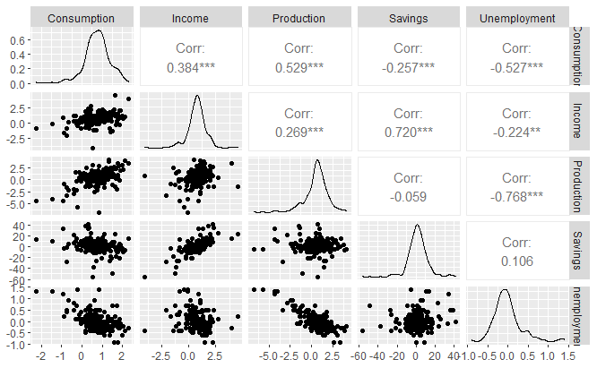

```r
us_change %>%
  as_tibble() %>%
  select(-Quarter) %>%
  GGally::ggpairs()
```

**Una correlación, por más fuerte que sea entre dos variables, no puede implicar por sí misma causalidad.**

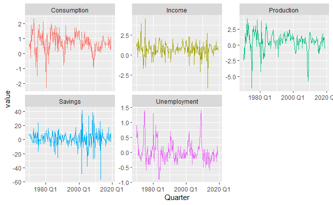

```r
us_change %>%
  pivot_longer(cols = -Quarter) %>%
  ggplot(aes(x = Quarter, y = value, color = name)) +
  geom_line() +
  facet_wrap(~ name, scales = "free_y") +
  theme(legend.position = "none")
```

## Regresión lineal simple

Realizamos un primer modelo, donde utilizaremos de variable predictora al ingreso disponible, para pronosticar el consumo.

```r
fit1 <- us_change %>%
  model(reg_lin_simple = TSLM(Consumption ~ Income)
        )
fit1 %>%  report()
```

```
Series: Consumption
Model: TSLM

Residuals:
     Min       1Q   Median       3Q      Max
-2.58236 -0.27777  0.01862  0.32330  1.42229

Coefficients:
            Estimate Std. Error t value Pr(>|t|)
(Intercept)  0.54454    0.05403  10.079  < 2e-16 ***
Income       0.27183    0.04673   5.817  2.4e-08 ***
---
Signif. codes:
0 ‘***’ 0.001 ‘**’ 0.01 ‘*’ 0.05 ‘.’ 0.1 ‘ ’ 1

Residual standard error: 0.5905 on 196 degrees of freedom
Multiple R-squared: 0.1472, Adjusted R-squared: 0.1429
F-statistic: 33.84 on 1 and 196 DF, p-value: 2.4022e-08
```

$$H_0: \beta_i = 0$$

$$H_0: \beta_1 = \beta_2 = \beta_3 = \ldots = 0$$

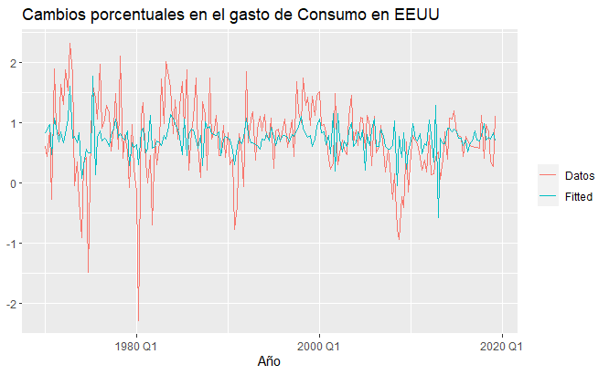

```r
augment(fit1) %>%
  ggplot(aes(x = Quarter)) +
  geom_line(aes(y = Consumption, color = "Datos")) +
  geom_line(aes(y = .fitted, color = "Fitted"))+
  xlab("Año") + ylab(NULL) +
  ggtitle("Cambios porcentuales en el gasto de Consumo en EEUU") +
  guides(color = guide_legend(title = NULL))
```

El modelo no parece capturar adecuadamente la variación de los datos reales.

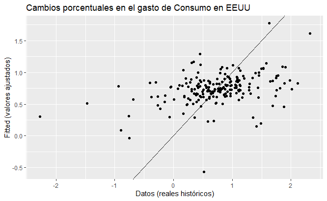

```r
augment(fit1) %>%
  ggplot(aes(x = Consumption, y = .fitted)) +
  geom_point() +
  ylab("Fitted (valores ajustados)") +
  xlab("Datos (reales históricos)") +
  ggtitle("Cambios porcentuales en el gasto de Consumo en EEUU") +
  geom_abline(intercept = 0, slope = 1)
```

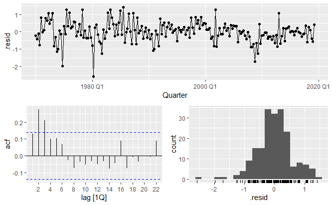

```r
fit1 %>%
  gg_tsresiduals()
```

```r
augment(fit1) %>%
  features(.resid, ljung_box, lag= 10, dof = 2)
```

| .model | lb_stat | lb_pvalue |
| --- | --- | --- |
| reg_lin_simple | 35.07754 | 2.588274e-05 |

Es evidente que este modelo se puede mejorar. Probemos incluyendo las otras predictoras.

## Regresión lineal múltiple

```r
fit2 <- us_change %>%
  model(
    reg_lin_multiple = TSLM(Consumption ~ Income + Production +
                              Savings + Unemployment)
  )
report(fit2)
```

```
Series: Consumption
Model: TSLM

Residuals:
     Min       1Q   Median       3Q      Max
-0.90555 -0.15821 -0.03608  0.13618  1.15471

Coefficients:
              Estimate Std. Error t value Pr(>|t|)
(Intercept)   0.253105   0.034470   7.343 5.71e-12 ***
Income        0.740583   0.040115  18.461  < 2e-16 ***
Production    0.047173   0.023142   2.038   0.0429 *
Savings      -0.052890   0.002924 -18.088  < 2e-16 ***
Unemployment -0.174685   0.095511  -1.829   0.0689 .
---
Signif. codes:
0 ‘***’ 0.001 ‘**’ 0.01 ‘*’ 0.05 ‘.’ 0.1 ‘ ’ 1

Residual standard error: 0.3102 on 193 degrees of freedom
Multiple R-squared: 0.7683, Adjusted R-squared: 0.7635
F-statistic:   160 on 4 and 193 DF, p-value: < 2.22e-16
```

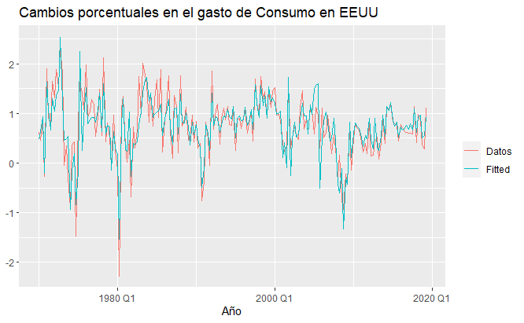

```r
augment(fit2) %>%
  ggplot(aes(x = Quarter)) +
  geom_line(aes(y = Consumption, color = "Datos")) +
  geom_line(aes(y = .fitted, color = "Fitted"))+
  xlab("Año") + ylab(NULL) +
  ggtitle("Cambios porcentuales en el gasto de Consumo en EEUU") +
  guides(color = guide_legend(title = NULL))
```

Este modelo parece capturar más variación de los datos históricos.

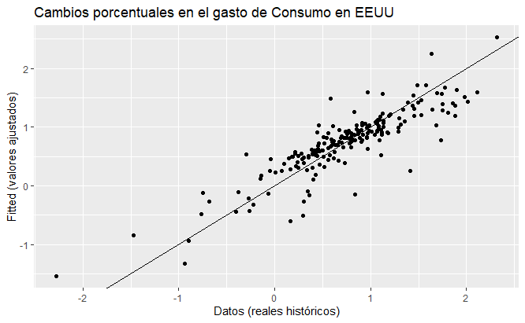

```r
augment(fit2) %>%
  ggplot(aes(x = Consumption, y = .fitted)) +
  geom_point() +
  ylab("Fitted (valores ajustados)") +
  xlab("Datos (reales históricos)") +
  ggtitle("Cambios porcentuales en el gasto de Consumo en EEUU") +
  geom_abline(intercept = 0, slope = 1)
```

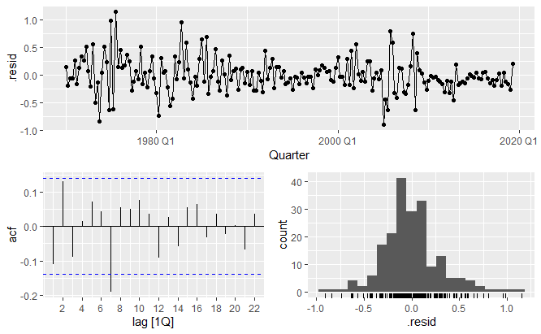

```r
fit2 %>%
  gg_tsresiduals()
```

```r
augment(fit2) %>%
  features(.resid, ljung_box, lag= 10, dof = 2)
```

| .model | lb_stat | lb_pvalue |
| --- | --- | --- |
| reg_lin_multiple | 18.86532 | 0.01559674 |

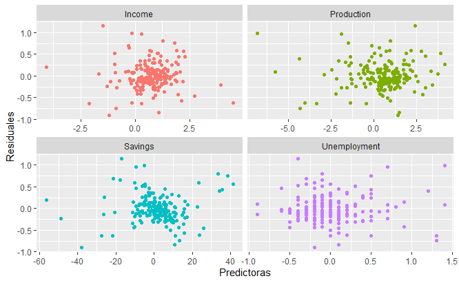

```r
df <- left_join(us_change, residuals(fit2), by = "Quarter")
df %>%
  select(-c(Consumption, .model)) %>%
  pivot_longer(cols = c(Income:Unemployment)) %>%
  ggplot(aes( x = value, y = .resid, color = name)) +
  geom_point() + ylab("Residuales") + xlab("Predictoras") +
  facet_wrap(~ name, scales = "free_x") +
  theme(legend.position = "none")
```

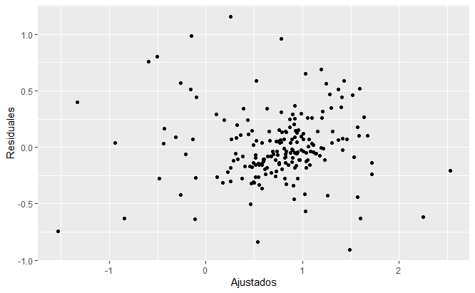

```r
augment(fit2) %>%
  ggplot(aes(x = .fitted, y = .resid)) +
  geom_point() +
  labs(x = "Ajustados", y = "Residuales")
```

```r
glance(fit2) %>%
  select(adj_r_squared, AIC, AICc, BIC)
```

| adj_r_squared | AIC | AICc | BIC |
| --- | --- | --- | --- |
| 0.7634805 | -456.5799 | -456.1401 | -436.8503 |

```r
fit3 <- us_change %>%
  model(r1 = TSLM(Consumption ~ Income),
        r2 = TSLM(Consumption ~ Income + Production),
        r3 = TSLM(Consumption ~ Income + Production + Savings + Unemployment),
        r4 = TSLM(Consumption ~ Income + Production + Savings))
fit3 %>%
  glance() %>%
  select(.model, adj_r_squared, AIC, AICc, BIC)
```

| .model | adj_r_squared | AIC | AICc | BIC |
| --- | --- | --- | --- | --- |
| r1 | 0.1428848 | -204.5925 | -204.4688 | -194.7277 |
| r2 | 0.3360267 | -254.1608 | -253.9535 | -241.0077 |
| r3 | 0.7634805 | -456.5799 | -456.1401 | -436.8503 |
| r4 | 0.7606214 | -455.1775 | -454.8650 | -438.7362 |

```r
fit3 %>%
  select(r3) %>%
  report()
```

```
Series: Consumption
Model: TSLM

Residuals:
     Min       1Q   Median       3Q      Max
-0.90555 -0.15821 -0.03608  0.13618  1.15471

Coefficients:
              Estimate Std. Error t value Pr(>|t|)
(Intercept)   0.253105   0.034470   7.343 5.71e-12 ***
Income        0.740583   0.040115  18.461  < 2e-16 ***
Production    0.047173   0.023142   2.038   0.0429 *
Savings      -0.052890   0.002924 -18.088  < 2e-16 ***
Unemployment -0.174685   0.095511  -1.829   0.0689 .
---
Signif. codes:
0 ‘***’ 0.001 ‘**’ 0.01 ‘*’ 0.05 ‘.’ 0.1 ‘ ’ 1

Residual standard error: 0.3102 on 193 degrees of freedom
Multiple R-squared: 0.7683, Adjusted R-squared: 0.7635
F-statistic:   160 on 4 and 193 DF, p-value: < 2.22e-16
```

## Selección de predictoras

1. Escoger subconjuntos de predictoras y probarlo.
2. Backwards stepwise regression:
- Empezamos con un modelo que contenga todas las predictoras.
- Quitamos una a la vez.
- Mantenemos el modelo si mejora la medida de desempeño predictivo ($\bar{R}^2$, AICc,…).
- Seguirlo haciendo hasta no encontrar mejoras adicionales.
3. Forwards stepwise regression:
- Comenzar con un modelo que solo incluya al intercepto.
- Se van agregando las predictoras una a la vez.
- La predictora que mejore más al modelo se mantiene.
- Se itera hasta no tener mejoría adicional.

## Pronóstico

### Pronósticos *ex-ante*

En estos pronósticos solo se utiliza información disponible hasta el último dato del histórico. A estos pronósticos se les considera como **pronósticos reales**. Aquí las predictoras se deben pronosticar antes de poder producir el pronóstico de la variable de interés.

### Pronósticos *ex-post*

Con estos pronósticos se utiliza información real disponible de las predictoras. Estos pronósticos ya no son **reales** (en el sentido estricto). La variable a pronosticar ($y$) sigue siendo desconocida.

### Pronósticos basados en escenarios

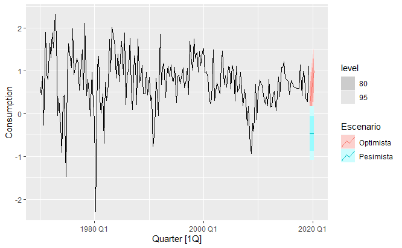

```r
fit_escenarios <- us_change %>%
  model(lineal = TSLM(Consumption ~ Income + Savings + Unemployment))
# Necesitamos agregar nuevos datos de las predictoras
optimista_futuro <- new_data(us_change,4) %>%
  mutate(Income = c(0, 0.3, 0.7,1), Savings = 0.5, Unemployment = 0)

pesimista_futuro <- new_data(us_change,4) %>%
  mutate(Income = -1, Savings = -0.5, Unemployment = 0)

fc_optimista <- forecast(fit_escenarios, new_data = optimista_futuro) %>%
  mutate(Escenario = "Optimista") %>%
  as_fable(response = "Consumo", key = "Escenario")

fc_pesimista <- forecast(fit_escenarios, new_data = pesimista_futuro) %>%
  mutate(Escenario = "Pesimista") %>%
  as_fable(response = "Consumo", key = "Escenario")

us_change %>%
  autoplot(Consumption) +
  autolayer(bind_rows(fc_optimista,fc_pesimista))
```

# Producción de cerveza

Los datos.

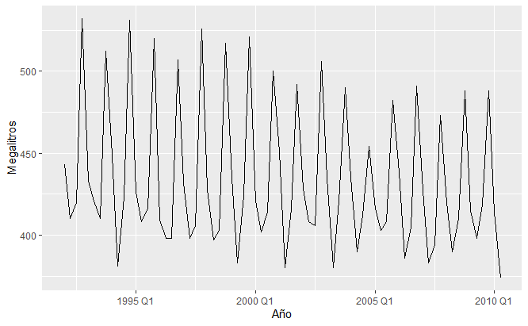

```r
cerveza <- aus_production %>%
  filter(year(Quarter)>=1992)

cerveza %>%
  autoplot(Beer) +
  labs(x = "Año", y = "Megalitros")
```

Existe una variable predictora para definir la tendencia de la serie. Para esto utilizaríamos simplemente `trend()`. Adicionalmente, existe la predictora `season()` que genera en automático las variables *dummy* estacionales.

```r
fit_cerveza <- cerveza %>%
  model(TSLM(Beer ~ trend() + season() )
        )
report(fit_cerveza)
```

```
Series: Beer
Model: TSLM

Residuals:
     Min       1Q   Median       3Q      Max
-42.9029  -7.5995  -0.4594   7.9908  21.7895

Coefficients:
               Estimate Std. Error t value Pr(>|t|)
(Intercept)   441.80044    3.73353 118.333  < 2e-16 ***
trend()        -0.34027    0.06657  -5.111 2.73e-06 ***
season()year2 -34.65973    3.96832  -8.734 9.10e-13 ***
season()year3 -17.82164    4.02249  -4.430 3.45e-05 ***
season()year4  72.79641    4.02305  18.095  < 2e-16 ***
---
Signif. codes:
0 ‘***’ 0.001 ‘**’ 0.01 ‘*’ 0.05 ‘.’ 0.1 ‘ ’ 1

Residual standard error: 12.23 on 69 degrees of freedom
Multiple R-squared: 0.9243, Adjusted R-squared: 0.9199
F-statistic: 210.7 on 4 and 69 DF, p-value: < 2.22e-16
```

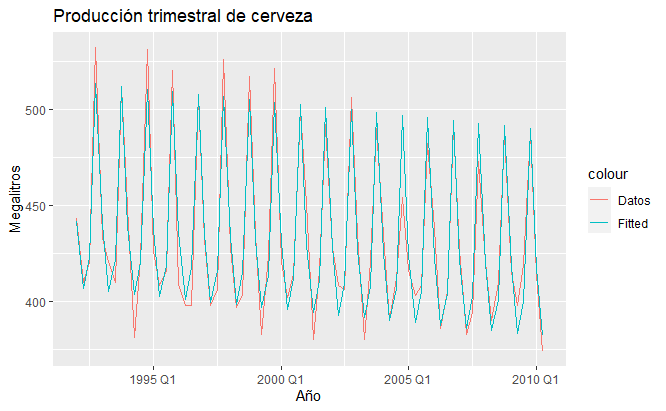

```r
augment(fit_cerveza) %>%
  ggplot(aes(x = Quarter)) +
  geom_line(aes(y = Beer, color = "Datos")) +
  geom_line(aes(y = .fitted, color = "Fitted")) +
  labs(x = "Año", y = "Megalitros", title = "Producción trimestral de cerveza")
```

$$x_{1,t} = \sin(\frac{2\pi t}{m}), x_{2,t} = \cos(\frac{2\pi t}{m}), x_{3,t} = \sin(\frac{4\pi t}{m}), x_{4,t} = \cos(\frac{4\pi t}{m})$$
Necesitamos especificar cuántos términos de la serie de Fourier queremos utilizar. Esto está restringido a máximo $m / 2$.

```r
fourier_cerveza <- cerveza %>%
  model(TSLM(Beer ~ trend() + fourier(K = 2)))

report(fourier_cerveza)
```

```
Series: Beer
Model: TSLM

Residuals:
     Min       1Q   Median       3Q      Max
-42.9029  -7.5995  -0.4594   7.9908  21.7895

Coefficients:
                    Estimate Std. Error t value Pr(>|t|)
(Intercept)        446.87920    2.87321 155.533  < 2e-16 ***
trend()             -0.34027    0.06657  -5.111 2.73e-06 ***
fourier(K = 2)C1_4   8.91082    2.01125   4.430 3.45e-05 ***
fourier(K = 2)S1_4 -53.72807    2.01125 -26.714  < 2e-16 ***
fourier(K = 2)C2_4 -13.98958    1.42256  -9.834 9.26e-15 ***
---
Signif. codes:
0 ‘***’ 0.001 ‘**’ 0.01 ‘*’ 0.05 ‘.’ 0.1 ‘ ’ 1

Residual standard error: 12.23 on 69 degrees of freedom
Multiple R-squared: 0.9243, Adjusted R-squared: 0.9199
F-statistic: 210.7 on 4 and 69 DF, p-value: < 2.22e-16
```

# Tiempos ganadores en el maratón de Boston

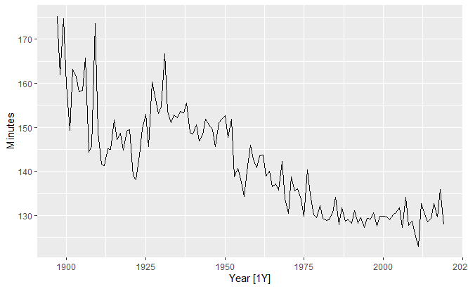

```r
boston_men <- boston_marathon %>%
  filter(Event == "Men's open division") %>%
  mutate(Minutes = as.numeric(Time)/60)
boston_men %>%
  autoplot(Minutes)
```

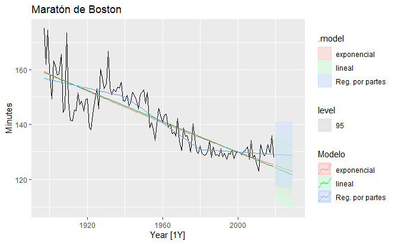

```r
fit_boston <- boston_men %>%
  model(
    lineal = TSLM(Minutes ~ trend()),
    exponencial = TSLM(log(Minutes) ~ trend()),
    `Reg. por partes` = TSLM(Minutes ~ trend(knots = c(1940, 1980)))
  )
fc_boston <- fit_boston %>% forecast(h = 10)

boston_men %>%
  autoplot(Minutes) +
  geom_line(aes(y = .fitted, color = .model), data = fitted(fit_boston)) +
  autolayer(fc_boston, alpha = 0.5, level = 95) +
  ggtitle("Maratón de Boston") +
  guides(color = guide_legend(title = "Modelo"))
```